# INLA spatial and spatio-temporal mortality screen

## Decision

Use **INLA as the main bounded-response driver**, with a Bernoulli model for whether mortality occurred and a conditional beta model for positive mortality. Carry the persistent spatial field into the operational GBR model. It improves prediction at unsurveyed reefs and can represent persistent unmeasured susceptibility or buffering.

Keep independent event-specific spatial fields as a diagnostic and nowcasting extension. They are marginally better when other reefs from the same event are available, but their latent event surface is not known before mortality data arrive. The AR1 event field should not be the default: the estimated correlation between adjacent event surfaces is negative, and the five events are unevenly spaced in time.

Restore current speed to the operational ecological core and carry summer SST skewness, summer excess kurtosis and wet-season median chlorophyll as a grouped, regularised candidate. Together they improve pooled reef-blocked RMSE to 13.9% and predictive R2 to 38.4%. Partially pooling the five prespecified DHW interactions improves these further to 13.7% and 40.5%. Individual coefficients remain uncertain and held-event gains vary among programmes, so predictions take precedence over single-coefficient claims.

The time-varying DHW response is worth retaining as a sensitivity, but it does not currently demonstrate adaptation. Its event deviations and the direct DHW-by-repeat-exposure interaction remain uncertain. Repeat exposure could also represent acclimatisation, community filtering, selective mortality or changes in observation coverage.

## What was fitted

The screen uses 537 observations, 139 reefs, 304 reef-events and five mass bleaching events (2016, 2017, 2020, 2022 and 2024). Six likelihood columns are fitted jointly: occurrence and positive magnitude for LTMP, Manta tow and MMP. Programme/component intercepts and beta precisions differ, while the ecological coefficients and latent reef-event, event and spatial effects are shared.

This is a deliberately strong shared-response screen. The formal model should estimate programme/component calibration loadings rather than assume every layer has exactly the same logit-scale response. Predictions in this screen multiply the posterior marginal means for occurrence and magnitude. Posterior sampling should be used for the final expected mortality and uncertainty maps.

| Candidate | Scientific role | Operational use |
| --- | --- | --- |
| No spatial field | Baseline joint bounded model | Yes |
| Persistent spatial field | Stable reef-scale susceptibility/refugia | Yes |
| Independent event fields | Event-specific residual geography | With partial event surveys |
| AR1 event fields | Temporal borrowing between event surfaces | Sensitivity only |
| Persistent field + varying DHW slope | Changing thermal response across events | Yes, if validated |
| Add current speed | Hydrodynamic buffering and DHW modification | Yes; 2024 partly climatological |
| Add current, SST shape and Chl-a | Thermal trajectory and productivity candidate | Carry into formal partial pooling |
| Full features with partial pooling | Layer deviations for five DHW interactions | Preferred within-event mapping candidate |

The mesh has 352 nodes. Its PC prior assigns 50% probability that the spatial range is below 200 km and 5% probability that latent-field standard deviation exceeds 0.7 on the shared linear predictor.

## Predictive comparison

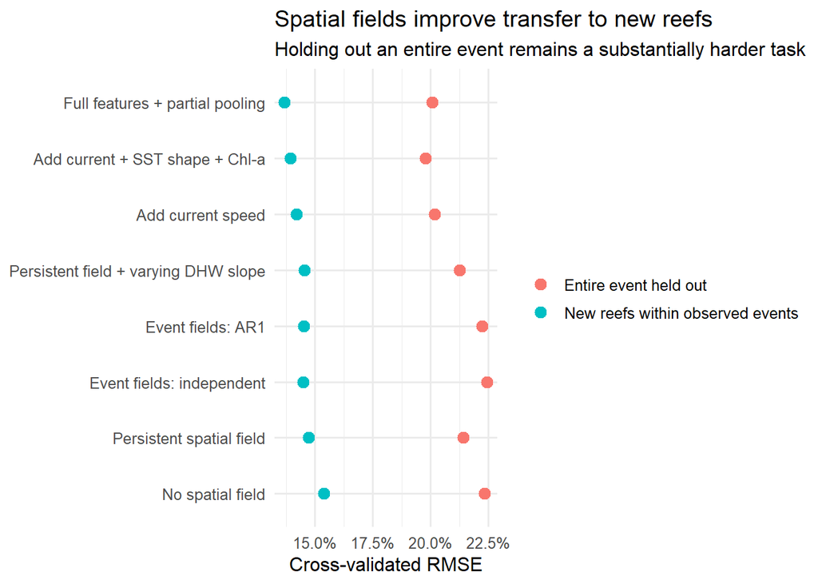

| Model | Validation | RMSE | Predictive R2 | Bias | Severe observed | Severe predicted | Severe RMSE | False extreme rate |
| --- | --- | --- | --- | --- | --- | --- | --- | --- |
| Add current + SST shape + Chl-a | Entire event held out | 19.8% | -0.24 | 3.3% | 61.7% | 39.8% | 41.7% | 12.0% |
| Full features + partial pooling | Entire event held out | 20.1% | -0.28 | 3.9% | 61.7% | 42.2% | 40.9% | 12.9% |
| Add current speed | Entire event held out | 20.2% | -0.29 | 2.6% | 61.7% | 33.5% | 43.0% | 12.9% |
| Persistent field + varying DHW slope | Entire event held out | 21.2% | -0.43 | 3.4% | 61.7% | 34.3% | 42.4% | 13.3% |
| Persistent spatial field | Entire event held out | 21.4% | -0.46 | 3.4% | 61.7% | 34.8% | 42.9% | 13.3% |
| Event fields: AR1 | Entire event held out | 22.2% | -0.57 | 4.8% | 61.7% | 36.3% | 42.9% | 14.8% |
| No spatial field | Entire event held out | 22.3% | -0.59 | 4.0% | 61.7% | 34.9% | 44.0% | 14.4% |
| Event fields: independent | Entire event held out | 22.4% | -0.60 | 5.2% | 61.7% | 36.6% | 42.7% | 15.0% |
| Full features + partial pooling | New reefs within observed events | 13.7% | 0.40 | -0.2% | 61.7% | 35.4% | 33.1% | 4.1% |
| Add current + SST shape + Chl-a | New reefs within observed events | 13.9% | 0.38 | -0.3% | 61.7% | 33.1% | 34.4% | 3.9% |
| Add current speed | New reefs within observed events | 14.2% | 0.36 | -0.2% | 61.7% | 32.4% | 35.4% | 4.8% |
| Event fields: AR1 | New reefs within observed events | 14.5% | 0.33 | -0.2% | 61.7% | 30.4% | 36.6% | 3.5% |
| Event fields: independent | New reefs within observed events | 14.5% | 0.33 | -0.2% | 61.7% | 30.3% | 36.4% | 4.6% |
| Persistent field + varying DHW slope | New reefs within observed events | 14.6% | 0.33 | -0.2% | 61.7% | 31.0% | 36.2% | 4.4% |
| Persistent spatial field | New reefs within observed events | 14.7% | 0.31 | -0.1% | 61.7% | 30.5% | 36.8% | 4.8% |
| No spatial field | New reefs within observed events | 15.4% | 0.25 | -1.0% | 61.7% | 26.3% | 41.1% | 4.6% |

For new reefs within known events, the non-spatial model explains 24.8% of held-out variation. Spatial candidates explain 31.1% to 33.2%, with RMSE falling from 15.4% to about 14.5%. The independent event field is the narrow winner, but the persistent field is operationally preferable because it can be projected before event mortality observations exist.

## Restored current and SST-shape features

The feature comparison holds the selected latent structure fixed: a persistent spatial field and event-varying DHW slope. It therefore tests added information, not a change in spatial complexity.

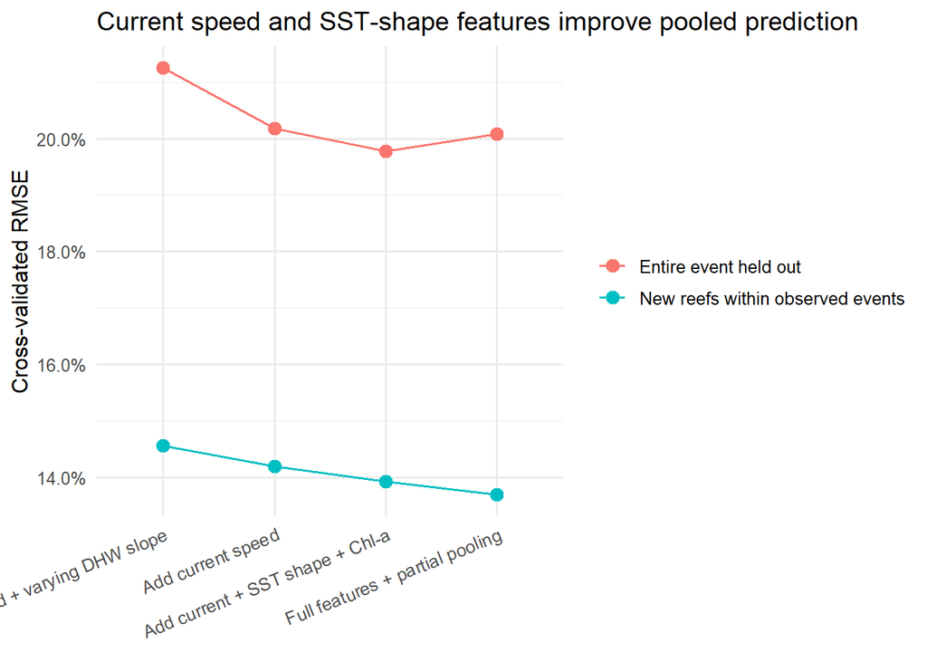

Current speed reduces pooled reef-blocked RMSE from 14.6% to 14.2% and leave-event-out RMSE from 21.2% to 20.2%. Adding SST skewness, excess kurtosis and wet-season Chl-a reduces them further to 13.9% and 19.8%. Pooled reef-blocked predictive R2 rises from 32.7% to 38.4%. Partial pooling reaches 13.7% RMSE and 40.5% predictive R2, while leave-event-out RMSE is 20.1%–a small loss relative to the completely shared full-feature model.

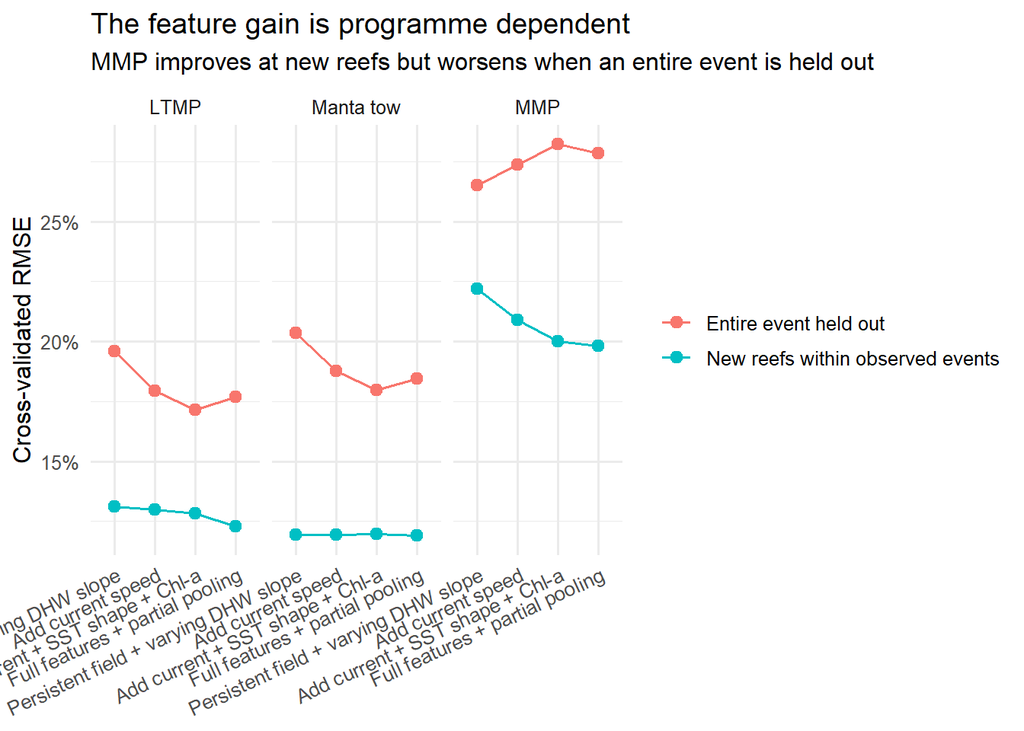

The shared full-feature candidate improves reef-blocked R2 to 40.9% for LTMP and 25.7% for MMP, while Manta is essentially unchanged near 40%. Partial pooling raises these to 45.7%, 26.9% and 40.3%, respectively. Under leave-event-out validation partial pooling improves MMP relative to the shared full model but is slightly worse for LTMP and Manta. This is a genuine mapping versus future-event trade-off, not a universal winner.

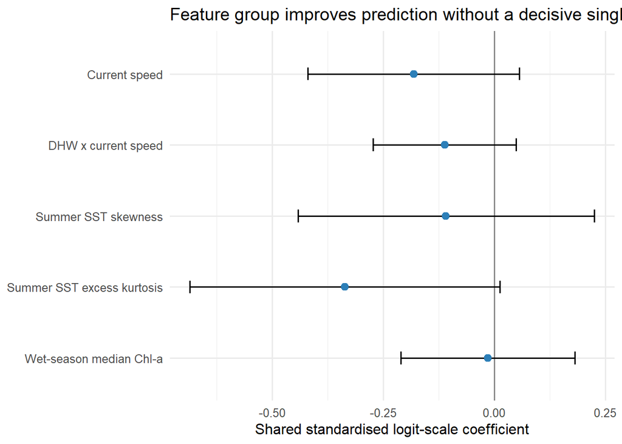

The current-speed main effect and DHW interaction are negative, consistent with hydrodynamic buffering, but their 95% intervals narrowly include zero. Excess kurtosis has the strongest new thermal-shape coefficient; skewness and Chl-a are more uncertain. Because summer skewness and kurtosis are strongly correlated, these coefficients should not be interpreted independently.

## What partial pooling changed

The agreed interactions for Acropora, novelty, freshwater/coloured water, cloud and current retain a common ecological coefficient. Each also receives six zero-centred deviations: occurrence and positive magnitude for LTMP, Manta and MMP. A PC prior shrinks unnecessary deviations back toward the common response.

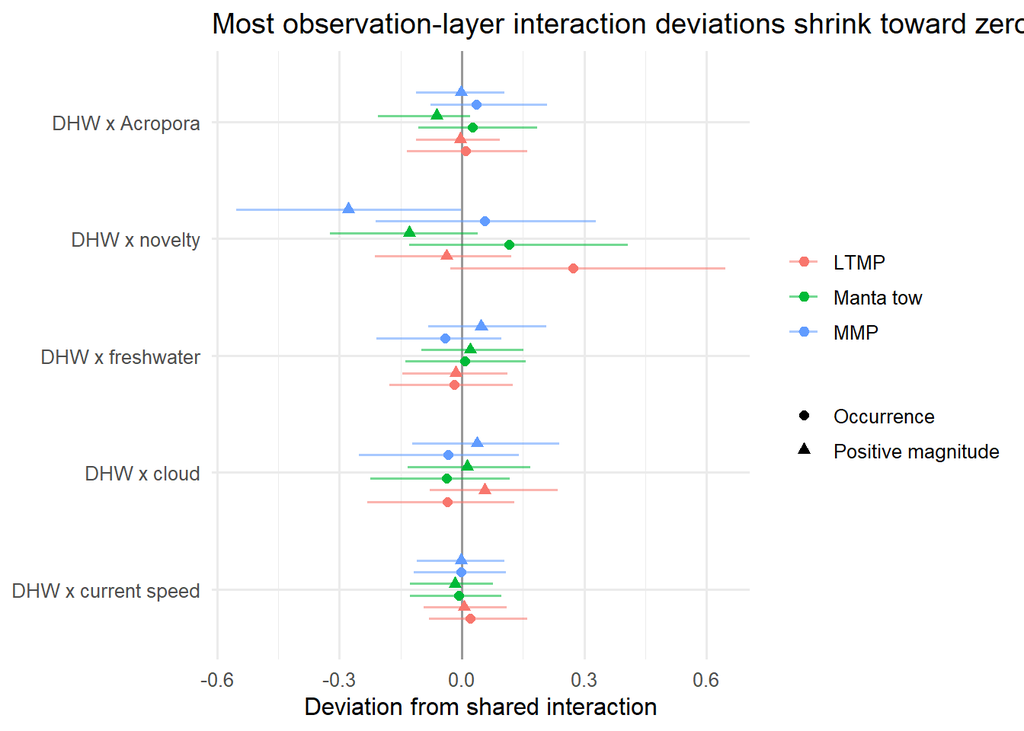

Most layer deviations are small and uncertain, supporting substantial sharing. The clearest exception is a more negative novelty effect in MMP positive mortality, while LTMP occurrence tends in the opposite direction. This is consistent with allowing limited programme/component flexibility rather than fitting unrelated ecological models.

Partial pooling raises the reef-blocked severe-case mean prediction from 33.1% to 35.4% and reduces severe RMSE from 34.4% to 33.1%. The observed severe mean is still 61.7%, so the severe-tail learner remains necessary.

## Severe mortality remains the key miss

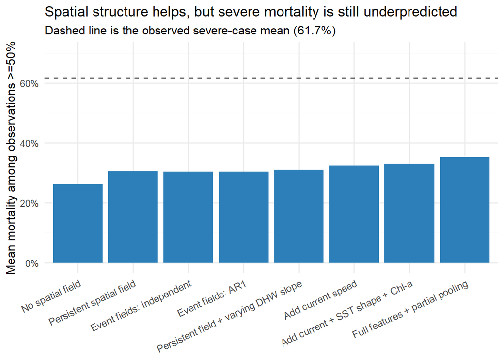

The persistent field raises the severe-case mean prediction from 26.3% to 30.5%; the varying-slope version reaches 31.0%. This remains far below the observed 61.7%. Spatial effects therefore recover structured residual risk but do not replace the planned severe-tail component or the nonlinear BRT expert.

For 2024 reef-blocked predictions, spatial models improve predictive R2 from 13.7% to 26.5–28.2%. Nevertheless, the 23 observations above 50% mortality average 62.3% observed and only about 33% predicted. When 2024 is completely held out, the persistent varying-slope model predicts the overall event mean slightly high (21.3% versus 17.6%) while still underpredicting its severe cases (40.0% versus 62.3%). Mean calibration can therefore conceal failure in the upper tail.

| Model | Validation | N | Observed mean | Predicted mean | RMSE | Predictive R2 | Severe N | Severe observed | Severe predicted |
| --- | --- | --- | --- | --- | --- | --- | --- | --- | --- |
| Add current + SST shape + Chl-a | Entire event held out | 218 | 17.6% | 20.9% | 25.3% | -0.52 | 23 | 62.3% | 45.9% |
| Add current speed | Entire event held out | 218 | 17.6% | 19.2% | 25.6% | -0.56 | 23 | 62.3% | 38.5% |
| Full features + partial pooling | Entire event held out | 218 | 17.6% | 21.9% | 26.0% | -0.61 | 23 | 62.3% | 47.5% |
| Persistent field + varying DHW slope | Entire event held out | 218 | 17.6% | 21.3% | 27.7% | -0.82 | 23 | 62.3% | 40.0% |
| Persistent spatial field | Entire event held out | 218 | 17.6% | 21.5% | 28.0% | -0.85 | 23 | 62.3% | 41.2% |
| Event fields: AR1 | Entire event held out | 218 | 17.6% | 24.0% | 29.2% | -1.02 | 23 | 62.3% | 43.6% |
| Event fields: independent | Entire event held out | 218 | 17.6% | 25.2% | 29.9% | -1.12 | 23 | 62.3% | 44.4% |
| No spatial field | Entire event held out | 218 | 17.6% | 25.0% | 29.9% | -1.12 | 23 | 62.3% | 43.5% |
| Full features + partial pooling | New reefs within observed events | 218 | 17.6% | 16.2% | 16.5% | 0.36 | 23 | 62.3% | 37.3% |
| Add current speed | New reefs within observed events | 218 | 17.6% | 15.9% | 16.7% | 0.34 | 23 | 62.3% | 35.2% |
| Add current + SST shape + Chl-a | New reefs within observed events | 218 | 17.6% | 16.0% | 16.7% | 0.34 | 23 | 62.3% | 35.3% |
| Event fields: AR1 | New reefs within observed events | 218 | 17.6% | 15.9% | 17.4% | 0.28 | 23 | 62.3% | 32.9% |
| Event fields: independent | New reefs within observed events | 218 | 17.6% | 15.9% | 17.4% | 0.28 | 23 | 62.3% | 33.0% |
| Persistent field + varying DHW slope | New reefs within observed events | 218 | 17.6% | 15.9% | 17.5% | 0.28 | 23 | 62.3% | 33.2% |
| Persistent spatial field | New reefs within observed events | 218 | 17.6% | 16.0% | 17.6% | 0.26 | 23 | 62.3% | 33.3% |
| No spatial field | New reefs within observed events | 218 | 17.6% | 15.0% | 19.1% | 0.14 | 23 | 62.3% | 28.9% |

## Spatial signal

The persistent field has a posterior median range of about 223 km, but its 95% interval is wide (39–1106 km). Its latent standard deviation is about 0.65 (0.28–1.42). This is meaningful residual spatial structure, but the range is not yet sharply identified by 139 irregularly sampled reefs.

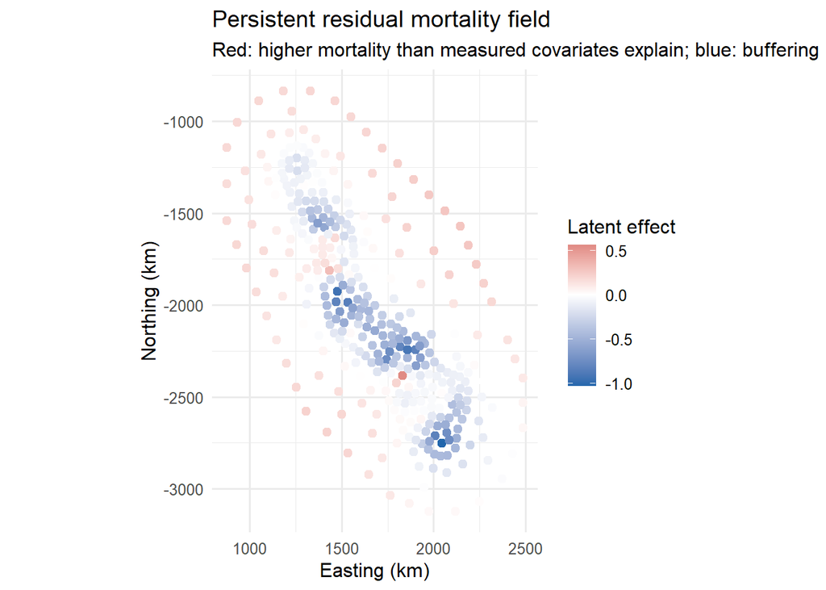

The field is a hypothesis generator, not a causal map. Persistent negative areas may point to cooling, upwelling, exposure or community features not yet represented. Positive areas may identify persistent freshwater, cyclone, COTS, composition or survey-process gaps. Field uncertainty and distance from observed reefs must accompany any GBR-wide projection.

## Event-specific geography

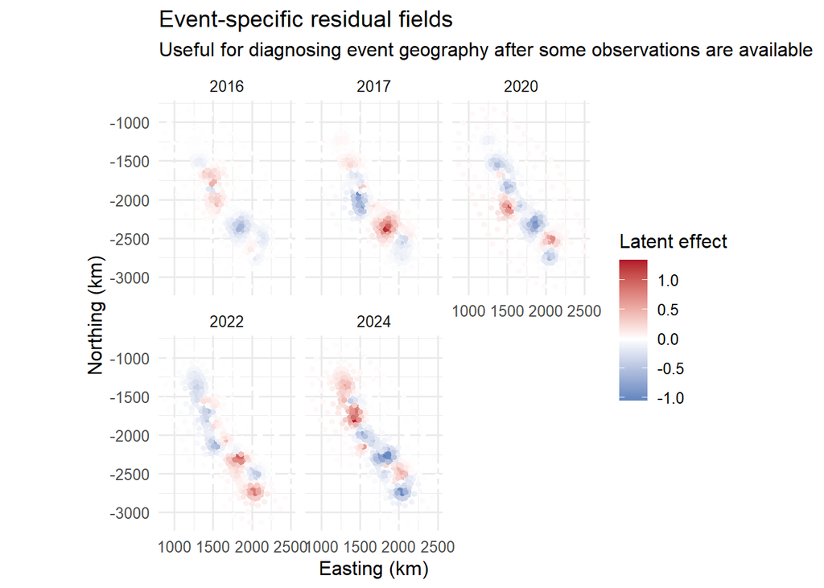

The AR1 event field has median spatial range near 138 km and latent standard deviation near 0.74. Its adjacent-event correlation is -0.49, with a 95% interval from -0.80 to approximately zero. That is evidence against treating the five observed event surfaces as a smoothly persistent temporal process. Independent event fields are simpler and slightly better under reef-blocked validation. They are suitable for retrospective inference or updating a map as event observations arrive, but not as an unobserved pre-survey correction.

## Repeat exposure and a changing DHW relationship

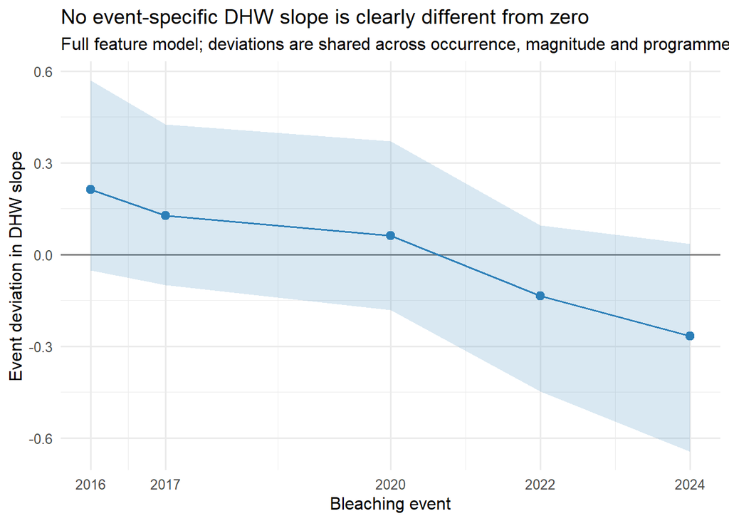

The posterior means decline across the sequence, but every 95% interval crosses zero. The direct DHW-by-number-of-events interaction is also centred close to zero in all candidates. This screen therefore does not establish adaptation. With only four reefs observed in all five events and 46 reefs observed in only one, the distinction between within-reef change and changing spatial/community composition is weak.

The adaptation question is better tested in the next model by separating:

1. within-reef repeat exposure and years since damaging exposure;
2. between-reef historical exposure;
3. event-specific environmental severity and composition;
4. persistent reef susceptibility; and
5. observation-programme calibration.

A continuous-time temporal model is preferable if enough events become available. In this screen, AR1 groups are adjacent event positions, not equal calendar intervals.

## Recommended formal INLA model

1. Keep the Bernoulli occurrence and conditional beta magnitude layers, with exact boundary handling and programme-specific intercepts and precision.
2. Restore current speed and its DHW interaction to the ecological core. Carry summer SST skewness, excess kurtosis and wet-season Chl-a as a jointly regularised feature group.
3. Use the persistent SPDE field in the operational model. Compare it with an independent event-field update when partial event data are available.
4. Retain repeat exposure, recovery interval and their DHW interactions as explicit hypotheses. Keep the RW1 event-varying DHW slope as a sensitivity, not an adaptation result.
5. Add programme/component calibration loadings and partially pooled feature slopes around the shared ecological response instead of forcing unit loadings.
6. Add the severe-tail expert and nonlinear BRT to the same nested validation workflow. Spatial INLA improves broad prediction but leaves the main extreme deficit intact.
7. Rank models primarily by reef-blocked, forward-event and leave-event-out prediction. Report WAIC, DIC, marginal likelihood and CPO as secondary within-likelihood diagnostics.
8. Generate GBR-wide posterior samples so occurrence, positive magnitude, spatial uncertainty and ensemble uncertainty are propagated jointly.

The operational deliverable should expose two maps: a pre-survey forecast using measured covariates plus the persistent field, and an optional event-updated map that learns an event-specific field from the first available mortality surveys.